# Replicating a Published Butterfly Biodiversity Analysis in R

ANOVA, detrended correspondence analysis (DCA), and correspondence analysis (CA)

Author

Nikolay Winslow

Published

September 24, 2026

## Overview

This report replicates the main analyses from Loos et al. (2014), a study of butterfly communities across different land-use types. The goals are to:

1. Prepare the data so that only arable and grassland sites remain.
2. Reproduce the study’s descriptive statistics and ANOVA results.
3. Reproduce the detrended correspondence analysis (DCA) shown in Figure 2 of the paper (without the environmental vectors).
4. Run a correspondence analysis (CA) on transformed data and compare it with the DCA.

The data is publicly available at [Dryad](https://doi.org/10.5061/dryad.97s1k). Where my results differ from the published ones, the differences are noted and discussed.

## Setup

```r
library(readxl)
library(vegan)
library(dplyr)

# Dataset: Loos et al. (2014) butterfly survey, publicly available on Dryad
# https://doi.org/10.5061/dryad.97s1k
data <- read_excel("Loos+et+al+2014+Butterflies.xls")
```

## 1. Data Preparation

The dataset contains site identifiers, species counts, and a final block of environmental variables. The steps below:

- remove forest sites (`LUtype == "F"`) so only arable and grassland sites remain,
- split the species counts from the environmental variables, and
- drop species that never occurred in the remaining sites (some species were recorded only in forest).

```r
# Keep only arable and grassland sites
data2 <- data %>%
  filter(LUtype != "F")

# Column layout: column 1 = site ID, then species counts, then the final
# 16 columns are environmental variables
n_env <- 16

env     <- data2[, (ncol(data2) - n_env + 1):ncol(data2)]
species <- data2[, 2:(ncol(data2) - n_env)]

# Remove species with no occurrences in the remaining sites
species <- species[, colSums(species) > 0]

# Land-use type as a factor, reused for colouring the ordination plots
lu      <- factor(data2$LUtype)
lu_cols <- seq_along(levels(lu))

cat("Sites:", nrow(species), "| Species:", ncol(species), "\n")
```

```
Sites: 120 | Species: 131
```

## 2. Descriptive Statistics and ANOVA

```r
# Totals and ranges
total_individuals <- sum(species)
num_species       <- ncol(species)
richness          <- rowSums(species > 0)  # species richness per site
abundance         <- rowSums(species)      # individuals per site

summary_stats <- list(
  total_individuals = total_individuals,
  num_species       = num_species,
  richness_range    = range(richness),
  abundance_range   = range(abundance)
)
print(summary_stats)
```

```
$total_individuals
[1] 19876

$num_species
[1] 131

$richness_range
[1]  3 47

$abundance_range
[1]   7 452
```

```r
# Most abundant species (proportion of all individuals)
species_rel <- sort(colSums(species) / total_individuals, decreasing = TRUE)
print(head(species_rel, 12))
```

```
            Plebejus_argus         Polyommatus_icarus
               0.284916482                0.172972429
           Maniola_jurtina      Coenonympha_pamphilus
               0.140470920                0.084524049
       Melanargia_galathea           Leptidea_sinapis
               0.052877843                0.024552224
     Coenonympha_glycerion            Everes_argiades
               0.021030388                0.019420407
              Pieris_rapae      Aphantopus_hyperantus
               0.018011672                0.016150131
              Minois_dryas Colias_alfacariensis.hyale
               0.012980479                0.009609579
```

```r
# Does species richness differ between land-use types?
anova_richness <- aov(richness ~ LUtype, data = data2)
summary(anova_richness)
```

```
             Df Sum Sq Mean Sq F value Pr(>F)
LUtype        1     82   81.68   1.332  0.251
Residuals   118   7237   61.33
```

```r
# Does abundance differ between land-use types?
anova_abundance <- aov(abundance ~ LUtype, data = data2)
summary(anova_abundance)
```

```
             Df  Sum Sq Mean Sq F value Pr(>F)
LUtype        1   15550   15550   1.514  0.221
Residuals   118 1211928   10271
```

**Comparison with the paper.** The statistics almost entirely match the published values. The exceptions are the range of species richness per site (3-47 here versus 3-45 in the paper) and the total counts of individuals and species, which differ slightly, possibly because of known taxonomic inconsistencies in the dataset. The most abundant species and the ANOVA results for richness and abundance match the paper. As the paper reports, the ANOVA results show little difference between arable and grassland sites in either richness or abundance.

## 3. Detrended Correspondence Analysis (DCA)

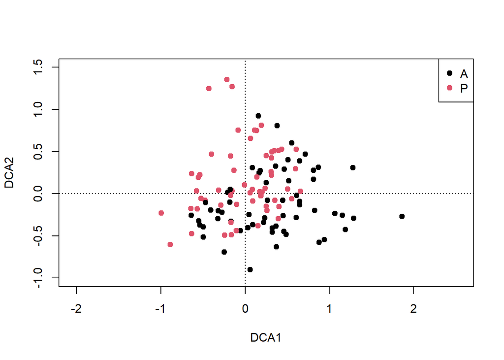

DCA of butterfly assemblages by site, coloured by land-use type (replication of Figure 2 without environmental vectors).

```r
dca_model <- decorana(species)

plot(dca_model, type = "n", xlim = c(-1.5, 2), ylim = c(-1, 1.5))
points(dca_model, display = "sites", col = as.integer(lu), pch = 19)
legend("topright", legend = levels(lu), col = lu_cols, pch = 19)
```

**Comparison with the paper.** The DCA was carried out successfully and matches Figure 2 of the study.

## 4. Correspondence Analysis (CA)

Butterfly counts are highly skewed, so the counts were log-transformed before running CA, using the `log` method in `vegan::decostand()` (log(x) + 1 for non-zero counts; zeros stay zero).

```r
species_log <- decostand(species, method = "log")

ca_model <- cca(species_log)

# Variance explained by each axis
eig_vals      <- eigenvals(ca_model)
var_explained <- eig_vals / sum(eig_vals)

cat(sprintf("Variance explained by CA1: %.1f%%\n", 100 * var_explained[1]))
```

```
Variance explained by CA1: 6.3%
```

```r
cat(sprintf("Variance explained by CA2: %.1f%%\n", 100 * var_explained[2]))
```

```
Variance explained by CA2: 4.2%
```

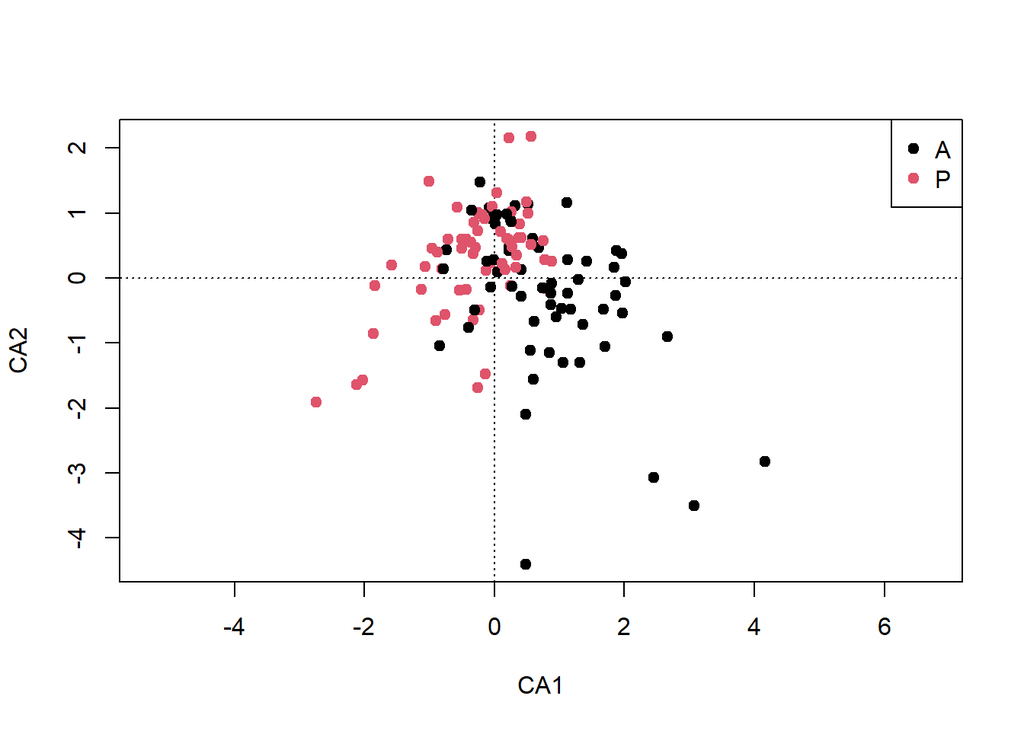

CA of log-transformed butterfly data by site, coloured by land-use type.

```r
plot(ca_model, type = "n")
points(ca_model, display = "sites", col = as.integer(lu), pch = 19)
legend("topright", legend = levels(lu), col = lu_cols, pch = 19)
```

**Interpretation.** The first two CA axes together explain only about 10% of the variance, which indicates that no single dominant factor explains the distribution of the butterflies. An arch effect is visible to some extent in the CA: points condense near the origin, while values spread farther apart on CA1 as CA2 decreases. This differs from the DCA, where arable sites are spread along DCA1 and grassland sites along DCA2, forming a very loose L-shaped pattern. The parabolic structure of the CA makes the groupings look more discrete than they are, whereas the detrended analysis shows only a vague trend. Given the low variance explained by each CA axis and CA’s tendency to produce an arch, the DCA appears to give the more accurate representation of the data.

## Conclusions

- The descriptive statistics, most abundant species, and ANOVA results replicate the published findings, apart from small differences in the richness range and in total individual and species counts.
- Species richness and abundance differ little between arable and grassland sites.
- The DCA reproduces Figure 2 of the paper.
- A CA of log-transformed data explains about 10% of the variance on its first two axes and shows an arch effect, so the DCA is the better representation of these data.

## Reference

Loos, J., Dorresteijn, I., Hanspach, J., Fust, P., Rakosy, L., & Fischer, J. (2014). Low-intensity agricultural landscapes in Transylvania support high butterfly diversity: implications for conservation. *PLoS ONE, 9*(7), e103256.

Loos, J., Dorresteijn, I., Hanspach, J., Fust, P., Rakosy, L., & Fischer, J. (2015). *Data from: Low-intensity agricultural landscapes in Transylvania support high butterfly diversity: implications for conservation* [Dataset]. Dryad. https://doi.org/10.5061/dryad.97s1k